# VisibilityNotifier2D

# VisibilityNotifier2D notifies when an object is on the screen

`VisibilityNotifier2D` emits a signal when it gets in and out of the screen. We use it together with other `Node2D` nodes to detect when they are visible.

It’s also possible to use this same feature based on a `Viewport` instead of the screen. We can use this for a minimap, warning a player that an enemy or a goal is close.

In this guide, you will learn how to:

- Set up a `VisibilityNotifier2D`.
- Use a `VisibilityNotifier2D` to remove objects that go off-screen.
- Cast a spell on all visible enemies.
- Suspend object behaviors using a `VisibilityEnabler2D`.

Contents:

- Setting up a VisibilityNotifier2D
- VisibilityNotifier2D’s key features
  - Screen and Viewport signals
  - Visibility check
  - VisibilityEnabler2D
- How to use a VisibilityNotifier2D in practice
  - Disappearing projectiles
  - Screen wide effects
  - Visibility based behavior pattern
  - Visibility based dialogue
  - Visibility based platforms
  - Visibility-based wandering enemy
- Your questions
  - What other nodes can interact with a VisibilityNotifier2D?
  - What other nodes have similar functionality? In which case should I use one instead of another?
  - How can I debug a VisibilityNotifier2D?
  - Troubleshooting

## Setting up a VisibilityNotifier2D

To use a `VisibilityNotifier2D`, you add it as a child of another `Node2D` and change its bounding box with the *Rect* property.

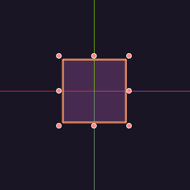

Using this rectangle, we can enclose a `Sprite`’s to tell when Godot should consider it is visible. We can use the `VisibilityNotifier2D`’s *Rect* property to adjust the visibility rectangle. Another way to do that is to use the handles to adjust the *Scale* settings. Both methods work.

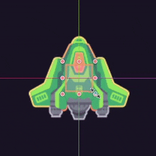

When the margins of the visible *Rect* enter the screen, the `VisibilityNotifier2D` emits the `screen_entered` signal. When no margins are inside the screen, it emits the `screen_exited` signal.

We can use these signals to enable or disable the `_physics_process()`, for instance.

```
onready var visibility_notifier := $VisibilityNotifier2D

func _ready() -> void:
    visibility_notifier.connect("screen_entered", self, "set_physics_process", [true])
    visibility_notifier.connect("screen_exited", self, "set_physics_process", [false])
```

## VisibilityNotifier2D’s key features

### Screen and Viewport signals

The `VisibilityNotifier2D` node offers four signals for us to tell when it entered the screen or exited it. It can also tell when it entered or exited a specific `Viewport`.

- `screen_entered`
- `screen_exited`
- `viewport_entered`
- `viewport_exited`

The `viewport_` signals pass a `Viewport` as an argument. These signals can be useful for split-screen games.

For example, an enemy may enter one player’s view but not the other’s. An enemy could be visible on the minimap but not on the screen yet.

### Visibility check

The `VisibilityNotifier2D` also offers the `is_on_screen()` method so we can check its visibility at any time.

This method can be useful for frame-by-frame checks or one-off checks.

An example of that is to optimize a RTS game. We can use `is_on_screen()` before a character dies. With that, we can prevent unnecessary processes. For instance, if the character isn’t on screen, we can call `queue_free()` instead of playing a whole animation.

```
func die() -> void:
    if visibility_notifier.is_on_screen():
        animation_player.play("die")
    else:
        queue_free()
```

### VisibilityEnabler2D

In this guide, we also work with the `VisibilityEnabler2D`: a `VisibilityNotifier2D` child class. It automates the toggling of some common processes. For instance, it can automatically disable the parent’s `_process()` function when off-screen.

We use the `VisibilityEnabler2D` as a direct child of a scene’s root node. Its properties can disable various processes on its sibling and parent nodes.

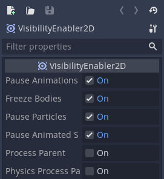

We can toggle any of these properties based on our needs. Apart from that, we can use a `VisibilityEnabler2D` like a `VisibilityNotifier2D`.

## How to use a VisibilityNotifier2D in practice

Now let’s see some examples of what we can do with these nodes.

### Disappearing projectiles

In games like space shooters or run and gun games, we don’t want the bullets to damage enemies off-screen, especially when players shouldn’t know about the existence of such enemies.

Take this *Mega Man X2* scenario as an example.

[figure not shown]

*Game: Mega Man X2 (1994)*

Players would be able to defeat the enemy without even knowing an enemy was coming. This could break the whole level design.

Another reason to delete projectiles that go off-screen is for optimization.

We can do this in three steps:

1. Add a `VisibilityNotifier2D` as a child of the *Bullet* scene.
2. Adjust the visibility *Rect* to match the *Bullet*’s texture.
3. Connect the `screen_exited` signal to the *Bullet*’s `queue_free()` method

In the GIF below, the bullet count goes down as bullets go off-screen. The `screen_exited` signal from the `VisibilityNotifier2D` connects to `queue_free()` to remove each bullet from the `SceneTree`.

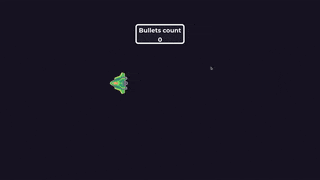

### Screen wide effects

Another use case for the `VisibilityNotifier2D` is when we want to apply an effect on all visible units. For example, an ultimate skill that damages all enemies on the screen.

*Chrono Trigger* is a good example of that, as it has skills that affect all enemies on screen.

[figure not shown]

*Game: Chrono Trigger (1995)*

We can add a `VisibilityNotifier2D` to the enemies. Then, using our key signals, we can add and remove nodes from a group called “visible.”

```
func _ready() -> void:
    _visibility_notifier.connect("screen_entered", self, "_on_VisibilityNotifier2D_screen_entered")
    _visibility_notifier.connect("screen_exited", self, "_on_VisibilityNotifier2D_screen_exited")


func _on_VisibilityNotifier2D_screen_entered() -> void:
    add_to_group("visible")


func _on_VisibilityNotifier2D_screen_exited() -> void:
    remove_from_group("visible")
```

Now we have access to all visible enemies, so we can damage them all when we cast the skill.

When casting the skill, we run through all enemies in the “enemy” group and check if they are visible. If they are, we apply the skill effect to that enemy.

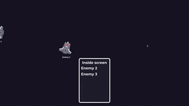

```
    if event.is_action_pressed("shoot"):
        for enemy in get_tree().get_nodes_in_group("enemy"):
            if not enemy.is_in_group("visible"):
                continue
            enemy.die()
```

### Visibility based behavior pattern

Some enemies shouldn’t perform their attack pattern if they are not visible.

In the below example, turrets can look at and shoot players even when players can’t see them.

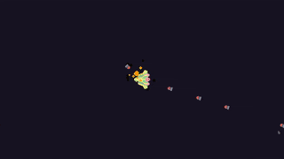

This is a questionable game design decision.

In this demo, we use the turrets from the *Turret Animation Queue* demo.

You can check it out to see how their attack pattern works. It uses an `AnimationPlayer` and queues up a sequence of animations.

We can add a `VisibilityEnabler2D` as their child and enable the *Pause Animation* property. This way, they won’t perform their attack pattern if they are not visible on-screen.

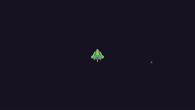

### Visibility based dialogue

When players run for the first time into an obstacle or something that can harm them, we can warn them or explain the obstacle with a dialogue box.

You may not want to use an `Area2D` in case the player somehow avoids or dodges the dialogue trigger.

Instead, you can use a `VisibilityNotifier2D` to guarantee that the warning dialogue appears as soon as players see the danger.

[figure not shown]

For that, we have a `VisibilityNotifier2D` with its visibility *Rect* covering the spikes pit.

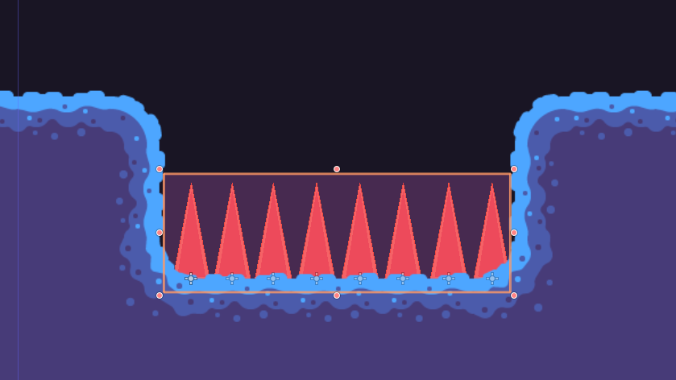

We also have the dialogue panel interface above the spike pit. It has an `AnimationPlayer` with two animations:

- `pop_panel`, which scales up the `Panel` and animates the *Label -> Percent Visible* property.
- `shrink_panel`, which scales down the `Panel`.

[figure not shown]

In the scene’s root node, we connect the `VisibilityNotifier2D`’s `screen_entered` signal to the `AnimationPlayer`’s `play()` method passing `pop_panel` as an extra argument.

Then we connect the `screen_exited` signal to the `AnimationPlayer`’s `play()` method passing `shrink_panel` as an extra argument.

```
func _ready() -> void:
    _spikes_visibility.connect("screen_entered", _ui_anim_player, "play", ["pop_panel"])
    _spikes_visibility.connect("screen_exited", _ui_anim_player, "play", ["shrink_panel"])
```

With that, we have a setup to pop instructions to a mechanic or hazard. We can use that for tutorials as well. For instance, when an enemy appears for the first time.

### Visibility based platforms

In action games, we have levels where designers choreograph how players play them. They take everything into account: timing, spacing, enemies, obstacles, hazards, and more.

For instance, in *Super Mario World*, we have the Way Cool level. On this level, players can use a moving saw to collect a Yoshi Coin.

[figure not shown]

*Game: Super Mario World (1990)*

If you play this level, you’ll notice that the saw starts moving as soon as the player sees it, so players have to react quickly.

To achieve this kind of mechanic, we use a moving platform. We set up a moving platform as follows:

1. Use a `Path2D` node as the scene root.
2. Add a `PathFollow2D` as its child.
3. Add a `KinematicBody2D`, the platform itself. It has a `Sprite` and a `CollisionShape2D` to match.
4. Toggle on the `KinematicBody2D`’s *Motion -> Sync to Physics* property.
5. Add a `RemoteTransform2D` as a `PathFollow2D` child. Pick the `KinematicBody2D` in its *Remote Path* property. Note that this step is necessary to fix [this bug](https://github.com/godotengine/godot/issues/54915). Otherwise, the `KinematicBody2D` could go as a direct child of the `PathFollow2D`.
6. Add an `AnimationPlayer` as a `PathFollow2D` child.
7. Create an autoplay animation that animates the `PathFollow2D`’s *Unit Offset* from `0.0` to `1.0` along `1.0` seconds.

The scene should look like this:

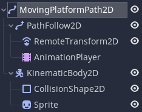

With that, we have our moving platform ready.

Then the final step to make it move as soon as it is visible is to add a `VisibilityEnabler2D` as a `PathFollow2D` child. Finally, toggle on the `VisibilityEnabler2D`’s *Pause Animations* property. It should be on by default, tho.

After that, it’s ready to be used in levels. All that’s left is to draw the platform’s movement path using the `Path2D` interface.

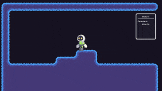

### Visibility-based wandering enemy

Have you seen a *Super Mario Bros.* Level 1-1 design analysis? It’s an interesting case to study. Level designers often highlight the first enemy’s behavior.

[figure not shown]

*Game: Super Mario Bros. (1985)*

We call this type of enemy a wanderer. It has no goal or real intelligence. It simply wanders around.

In this case, it performs its behavior when it’s visible on the screen. This prevents the enemy from hurting a player unaware of the game. Since this is the first level, players don’t know the game yet.

We can achieve this same behavior using a `VisibilityEnabler2D` as a child of our enemy. In this demo, we use the same enemy from the `KinematicBody2D` *Stomp* demo.

We also toggle off the *Pause Animated Sprites* property since the enemy’s script sets the animation logic. We don’t want the `VisibilityEnabler2D` controlling this animation logic.

*Enemy Scene Tree*

*VisibilityEnabler2D Settings*

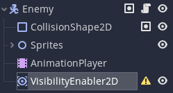

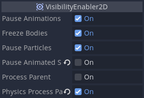

With that, the enemy should only move when visible on screen. This allows the players to learn how to move before facing an enemy.

[figure not shown]

## Your questions

### What other nodes can interact with a VisibilityNotifier2D?

`VisibilityNotifier2D` can interact with any `CanvasItem`. For `Control` nodes, it’s hard to think about any meaningful use case, as the intent is on `Node2D` nodes.

As for `VisibilityEnabler2D`, we covered how it interacts well with the `AnimationPlayer` node for moving platforms. However, it won’t have this same kind of interaction for the `Tween` node.

### What other nodes have similar functionality? In which case should I use one instead of another?

As seen in the visibility-based dialogue, we can also use an `Area2D` to detect a player’s proximity. Then, we can trigger behaviors based on that.

You can use `Area2D` nodes when you want a specific area to trigger a behavior only when players enter them. As an example, when players enter an enemy’s sight.

We use `VisibilityNotifier2D` when being on the screen is enough to trigger behavior.

As seen in the *Disappearing Projectiles* demo, another use case for `VisibilityNotifier2D` is for optimization. When the node leaves the screen, we can disable its processes or straight up delete it.

### How can I debug a VisibilityNotifier2D?

You can use Godot’s scene sync features. With them, you can play with the node moving it away and towards the screen’s viewport.

For that, in the top menu, toggle on the *Debug -> Synchronize Scene Changes*. Another recommendation is to toggle *Project Settings -> Window -> Always On Top*.

With that, you can move the `VisibilityNotifier2D` in and out of the screen and see the changes happening in real-time.

### Troubleshooting

Note the way the `VisibilityNotifier2D` works is not perfectly accurate. As of Godot 3.4, it uses a grid to tell if its bounding box is inside the screen. The screen doesn’t need to enclose the bounding box. If its bounding box enters the screen, Godot considers it visible.

You can change the grid cells resolution in [Project Settings -> World -> 2d -> Cell Size](https://docs.godotengine.org/en/stable/classes/class_projectsettings.html#class-projectsettings-property-world-2d-cell-size).

`VisibilityNotifier2D` only checks the bounds of the screen (or a `Viewport`). It cannot detect when it’s behind something that prevents the player from seeing the node.

If you need to detect when a `VisibilityNotifier2D` becomes covered up by another node, you can mix `VisibilityNotifier2D` with other systems like physics queries and the `Geometry` server to check for overlapping bodies and polygons.